# Beer Analysis Paper

Chance Robinson

10/22/2019

# Introduction

The analysis outlined in this paper seeks to address several questions of interest from the US Craft Beers industry. There were over 2,410 beers across 558 separate breweries identified in the study. Although the commissioned study is limited in scope and provides only a small sample of the available attributes, we are confident that it highlights some of the more obvious trends and regional differences in beer tastes. Two important factors in the flavor of any beer are the percentage of alcohol as well as the bitterness. We will delve into the specifics of this relationship among beer styles and across different regions of the United States in an attempt to gain better insights into market opportunities.

# Exploratory Data Analysis

## Library Imports

```r
library(tidyverse)
library(knitr)
library(kableExtra)
```

```r
library(maps)
library(mapproj)
library(class)
library(caret)
library(e1071)
```

## Load the csv data

```r
beers <- read.csv("../../data/Beers.csv", stringsAsFactors=FALSE)
breweries <- read.csv("../../data/Breweries.csv", stringsAsFactors=FALSE)
```

## Default Output

### Beers

```r
# head(beers)
# summary(beers)
# str(beers)

kable(head(beers)) %>%
  kable_styling(bootstrap_options = c("striped", "hover", "condensed", "responsive"))
```

| Name | Beer_ID | ABV | IBU | Brewery_id | Style | Ounces |
| --- | --- | --- | --- | --- | --- | --- |
| Pub Beer | 1436 | 0.050 | NA | 409 | American Pale Lager | 12 |
| Devil’s Cup | 2265 | 0.066 | NA | 178 | American Pale Ale (APA) | 12 |
| Rise of the Phoenix | 2264 | 0.071 | NA | 178 | American IPA | 12 |
| Sinister | 2263 | 0.090 | NA | 178 | American Double / Imperial IPA | 12 |
| Sex and Candy | 2262 | 0.075 | NA | 178 | American IPA | 12 |
| Black Exodus | 2261 | 0.077 | NA | 178 | Oatmeal Stout | 12 |

### Data Dictionary

| Column Name | Type | Description |
| --- | --- | --- |
| 1. Name | Character | Beer name |
| 2. Beer_ID | Integer | Unique identifier for beer |
| 3. ABV | Double | Alcohol by volume |
| 4. IBU | Integer | International Bitterness Units |
| 5. Brewery_id | Integer | Foreign key for brewery data set |
| 6. Style | Character | Beer type |
| 7. Ounces | Double | Number of ounces per serving |

### Breweries

```r
# head(breweries)
# summary(breweries)
# str(breweries)


kable(head(breweries)) %>%
  kable_styling(bootstrap_options = c("striped", "hover", "condensed", "responsive"))
```

| Brew_ID | Name | City | State |
| --- | --- | --- | --- |
| 1 | NorthGate Brewing | Minneapolis | MN |
| 2 | Against the Grain Brewery | Louisville | KY |
| 3 | Jack’s Abby Craft Lagers | Framingham | MA |
| 4 | Mike Hess Brewing Company | San Diego | CA |
| 5 | Fort Point Beer Company | San Francisco | CA |
| 6 | COAST Brewing Company | Charleston | SC |

### Data Dictionary

| Column Name | Type | Description |
| --- | --- | --- |
| 1. Brew_ID | Integer | Unique identifier for brewery |
| 2. Name | Integer | Brewery name |
| 3. City | Character | City of brewery |
| 4. State | Character | State of brewery |

## Clone data sets

- Create a pristine copy of the originals so that further refinements of the columns names, values, etc.. can be performed

### Beers Copy

```r
df_beers <- beers
colnames(df_beers)
```

```
## [1] "Name"       "Beer_ID"    "ABV"        "IBU"        "Brewery_id"
## [6] "Style"      "Ounces"
```

```r
names(df_beers) <- c("beer.name", "beer.id", "beer.abv", "beer.ibu", "beer.brewery.id", "beer.style", "beer.ounces")
# head(df_beers)
```

### Breweries Copy

```r
df_breweries <- breweries
colnames(df_breweries)
```

```
## [1] "Brew_ID" "Name"    "City"    "State"
```

```r
names(df_breweries) <- c("brewery.id", "brewery.name", "brewery.city", "brewery.state.abb")

# The state column has an extra white space at the end of the string
df_breweries <- df_breweries %>%
  mutate(brewery.state.abb = trimws(brewery.state.abb))

# head(df_breweries)
```

## State Lookup

- Washington D.C. added as an entry

```r
#makes a data frame with State abbreviation, name  and region
# df_state_lookup = data.frame(state.abb, state.name, state.region, stringsAsFactors=FALSE)
df_state_lookup = data.frame(state.abb, state.name, state.region, state.x77, stringsAsFactors=FALSE)
# df_state_lookup

# add the District of Columbia as a lookup value
df_state_lookup <- rbind(df_state_lookup, 'DC' = c("DC", "Washington D.C.", "South"))
# head(df_state_lookup[1:5])
```

# 1. Brewery Count by State

Question One: How many breweries are present in each state?

- Note that all 50 states have at least one brewery, in addition to the District of Columbia (Washington D.C.).

```r
df_breweries_state <- merge(df_breweries, df_state_lookup[1:5], by.x = "brewery.state.abb", by.y = "state.abb", all.x = TRUE)
# df_breweries_state

df_breweries_count_by_state <- df_breweries_state %>%
  count(state.name, sort = TRUE)

# head(df_breweries_count_by_state)

kable(df_breweries_count_by_state) %>%
  kable_styling(bootstrap_options = c("striped", "hover", "condensed", "responsive"))
```

| state.name | n |
| --- | --- |
| Colorado | 47 |
| California | 39 |
| Michigan | 32 |
| Oregon | 29 |
| Texas | 28 |
| Pennsylvania | 25 |
| Massachusetts | 23 |
| Washington | 23 |
| Indiana | 22 |
| Wisconsin | 20 |
| North Carolina | 19 |
| Illinois | 18 |
| New York | 16 |
| Virginia | 16 |
| Florida | 15 |
| Ohio | 15 |
| Minnesota | 12 |
| Arizona | 11 |
| Vermont | 10 |
| Maine | 9 |
| Missouri | 9 |
| Montana | 9 |
| Connecticut | 8 |
| Alaska | 7 |
| Georgia | 7 |
| Maryland | 7 |
| Oklahoma | 6 |
| Idaho | 5 |
| Iowa | 5 |
| Louisiana | 5 |
| Nebraska | 5 |
| Rhode Island | 5 |
| Hawaii | 4 |
| Kentucky | 4 |
| New Mexico | 4 |
| South Carolina | 4 |
| Utah | 4 |
| Wyoming | 4 |
| Alabama | 3 |
| Kansas | 3 |
| New Hampshire | 3 |
| New Jersey | 3 |
| Tennessee | 3 |
| Arkansas | 2 |
| Delaware | 2 |
| Mississippi | 2 |
| Nevada | 2 |
| North Dakota | 1 |
| South Dakota | 1 |
| Washington D.C. | 1 |
| West Virginia | 1 |

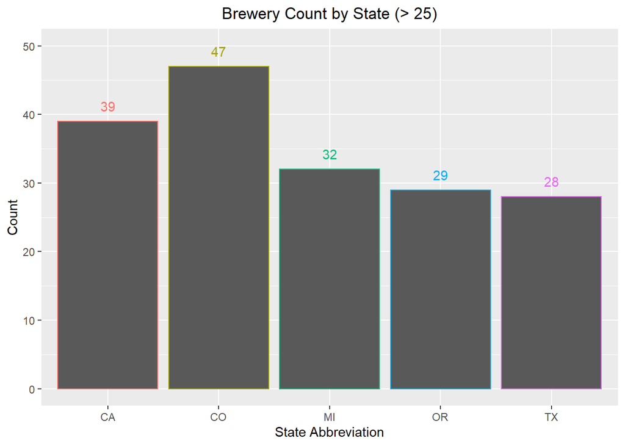

```r
df_breweries_state %>%
  group_by(brewery.state.abb) %>%
  filter(n() > 25) %>%
  ggplot(aes(x = brewery.state.abb, color=brewery.state.abb)) +
  geom_bar() +
  geom_text(stat='count', aes(label=..count..), vjust=-1) +
  ggtitle("Brewery Count by State (> 25)") +
  labs(x = "State Abbreviation", y = "Count") +
  theme(plot.title = element_text(hjust = 0.5)) + lims(y=c(0,50)) +
  # guides(fill=guide_legend(title=NULL))
  theme(legend.position = "none")
```

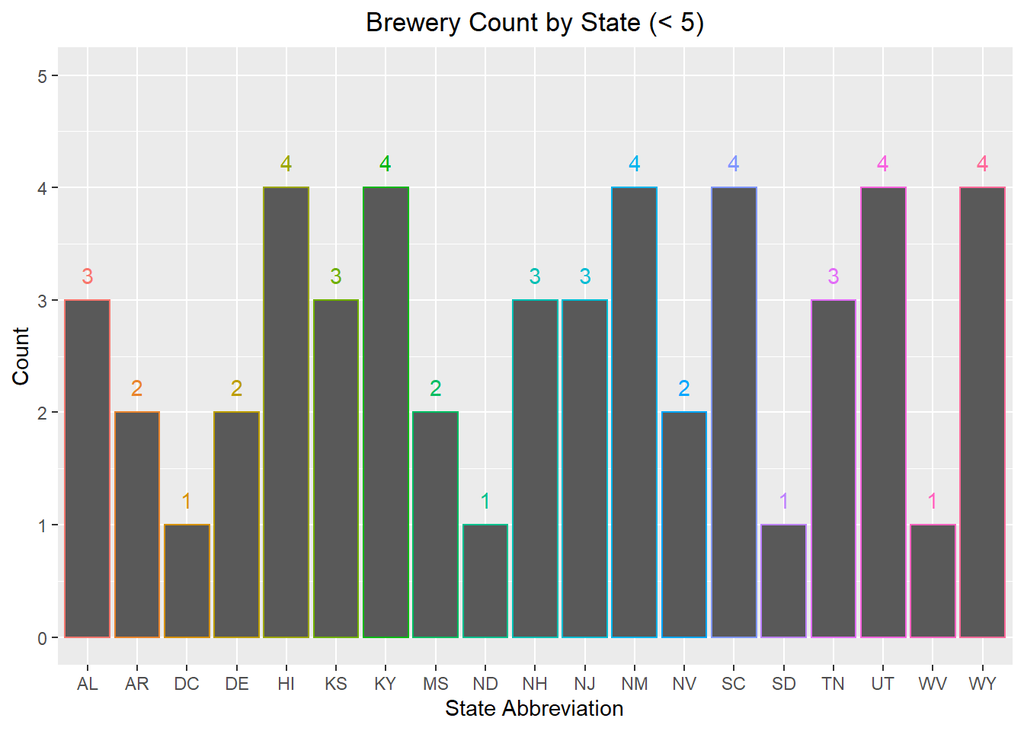

```r
df_breweries_state %>%
  group_by(brewery.state.abb) %>%
  filter(n() < 5) %>%
  ggplot(aes(x = brewery.state.abb, color=brewery.state.abb)) +
  geom_bar() +
  geom_text(stat='count', aes(label=..count..), vjust=-1) +
  ggtitle("Brewery Count by State (< 5)") +
  labs(x = "State Abbreviation", y = "Count") +
  theme(plot.title = element_text(hjust = 0.5)) + lims(y=c(0,5)) +
  # guides(fill=guide_legend(title=NULL))
  theme(legend.position = "none")
```

```r
df_merged <- merge(df_beers, df_breweries_state, by.x = "beer.brewery.id", by.y = "brewery.id")
# df_merged
```

# 2. Merge beer and breweries

Question Two: Merge beer data with the breweries data. Print the first 6 observations and the last six observations to check the merged file. (RMD only, this does not need to be included in the presentation or the deck.)

## First 6 observations of merged data sets

```r
# head(df_merged)

kable(head(df_merged)) %>%
  kable_styling(bootstrap_options = c("striped", "hover", "condensed", "responsive"))
```

| beer.brewery.id | beer.name | beer.id | beer.abv | beer.ibu | beer.style | beer.ounces | brewery.state.abb | brewery.name | brewery.city | state.name | state.region | Population | Income |
| --- | --- | --- | --- | --- | --- | --- | --- | --- | --- | --- | --- | --- | --- |
| 1 | Get Together | 2692 | 0.045 | 50 | American IPA | 16 | MN | NorthGate Brewing | Minneapolis | Minnesota | North Central | 3921 | 4675 |
| 1 | Maggie’s Leap | 2691 | 0.049 | 26 | Milk / Sweet Stout | 16 | MN | NorthGate Brewing | Minneapolis | Minnesota | North Central | 3921 | 4675 |
| 1 | Wall’s End | 2690 | 0.048 | 19 | English Brown Ale | 16 | MN | NorthGate Brewing | Minneapolis | Minnesota | North Central | 3921 | 4675 |
| 1 | Pumpion | 2689 | 0.060 | 38 | Pumpkin Ale | 16 | MN | NorthGate Brewing | Minneapolis | Minnesota | North Central | 3921 | 4675 |
| 1 | Stronghold | 2688 | 0.060 | 25 | American Porter | 16 | MN | NorthGate Brewing | Minneapolis | Minnesota | North Central | 3921 | 4675 |
| 1 | Parapet ESB | 2687 | 0.056 | 47 | Extra Special / Strong Bitter (ESB) | 16 | MN | NorthGate Brewing | Minneapolis | Minnesota | North Central | 3921 | 4675 |

## Last 6 observations of merged data sets

```r
# tail(df_merged)

kable(tail(df_merged)) %>%
  kable_styling(bootstrap_options = c("striped", "hover", "condensed", "responsive"))
```

|  | beer.brewery.id | beer.name | beer.id | beer.abv | beer.ibu | beer.style | beer.ounces | brewery.state.abb | brewery.name | brewery.city | state.name | state.region | Population | Income |
| --- | --- | --- | --- | --- | --- | --- | --- | --- | --- | --- | --- | --- | --- | --- |
| 2405 | 556 | Pilsner Ukiah | 98 | 0.055 | NA | German Pilsener | 12 | CA | Ukiah Brewing Company | Ukiah | California | West | 21198 | 5114 |
| 2406 | 557 | Heinnieweisse Weissebier | 52 | 0.049 | NA | Hefeweizen | 12 | NY | Butternuts Beer and Ale | Garrattsville | New York | Northeast | 18076 | 4903 |
| 2407 | 557 | Snapperhead IPA | 51 | 0.068 | NA | American IPA | 12 | NY | Butternuts Beer and Ale | Garrattsville | New York | Northeast | 18076 | 4903 |
| 2408 | 557 | Moo Thunder Stout | 50 | 0.049 | NA | Milk / Sweet Stout | 12 | NY | Butternuts Beer and Ale | Garrattsville | New York | Northeast | 18076 | 4903 |
| 2409 | 557 | Porkslap Pale Ale | 49 | 0.043 | NA | American Pale Ale (APA) | 12 | NY | Butternuts Beer and Ale | Garrattsville | New York | Northeast | 18076 | 4903 |
| 2410 | 558 | Urban Wilderness Pale Ale | 30 | 0.049 | NA | English Pale Ale | 12 | AK | Sleeping Lady Brewing Company | Anchorage | Alaska | West | 365 | 6315 |

# 3. Missing Values

Question Three: Address the missing values in each column

The IBU column in particular, has a relatively high percentage of missing values. This may complicate our analysis when comparing the data point to other fields that may have many more observations.

```r
df_has_na_values <- any(is.na(df_merged))
df_has_na_values
```

```
## [1] TRUE
```

```r
# which columns have missing values
df_na_columns = which(colSums(is.na(df_merged)) > 0)
df_na_columns
```

```
## beer.abv beer.ibu
##        4        5
```

```r
df_na_abv <- df_merged %>%
  filter(is.na(beer.abv))

na_abv_count <- dim(df_na_abv)[1]

df_na_ibu <- df_merged %>%
  filter(is.na(beer.ibu))

na_ibu_count <- dim(df_na_ibu)[1]


allmisscols <- sapply(df_merged, function(x) any(x == '' ))

# allmisscols

df_na_style <- df_merged %>%
  filter(beer.style=='')

na_style_count <- dim(df_na_style)[1]


total_count <- dim(df_merged)[1]
```

| Column Name | Count | % Missing |
| --- | --- | --- |
| 1. ABV | 62 | 2.57 |
| 2. IBU | 1005 | 41.7 |
| 3. Style | 5 | 0.21 |

# 4. Barplot of median values

Question Four: Compute the median alcohol content and international bitterness unit for each state. Plot a bar chart to compare.

## Alcohol by Volume

- Kentucky has the highest median ABV of any state in the dataset
- Utah has the lowest median ABV

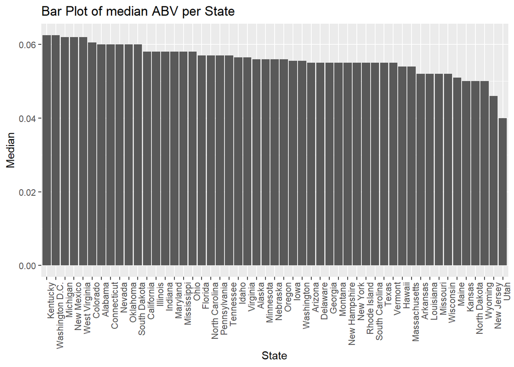

```r
# df_merged_abv_clean <- df_merged %>%
#   filter(!is.na(beer.abv)) %>%
#   group_by(state.name) %>%
#   summarize(beers.abv.median = median(beer.abv), count = n()) %>%
#   arrange(desc(beers.abv.median))

# head(df_merged_abv_clean)

# df_merged_abv_clean %>%
#   ggplot(aes(x = reorder(state.name, -beers.abv.median), y=as.numeric(beers.abv.median))) +
#   geom_bar(stat = "identity", position = "dodge") +
#   ggtitle("Bar Plot of median ABV per State") +
#   labs(x = "State", y = "Median") +
#   theme(axis.text.x = element_text(angle = 90, hjust = 1))

df_merged %>%
  select(state.name, beer.abv) %>%
  remove_missing(na.rm = TRUE) %>%
  group_by(state.name) %>%
  mutate(beers.abv.median = median(beer.abv)) %>%
  ggplot(aes(x = reorder(state.name, -beers.abv.median), y=beers.abv.median)) +
  geom_bar(stat = "identity", position = "dodge") +
  ggtitle("Bar Plot of median ABV per State") +
  labs(x = "State", y = "Median") +
  theme(axis.text.x = element_text(angle = 90, hjust = 1))
```

## International Bitterness Units

- Maine has the highest median IBU
- Wisconsin has the lowest

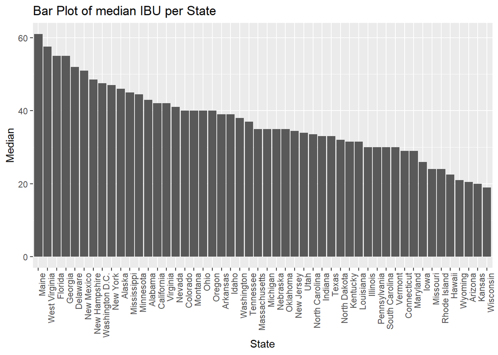

```r
# df_merged_ibu_clean <- df_merged %>%
#   filter(!is.na(beer.ibu)) %>%
#   group_by(state.name) %>%
#   summarize(beers.ibu.median = median(beer.ibu), count = n()) %>%
#   arrange(desc(beers.ibu.median))

# head(df_merged_ibu_clean)

# df_merged_ibu_clean %>%
#   ggplot(aes(x = reorder(state.name, -beers.ibu.median), y=as.numeric(beers.ibu.median))) +
#   geom_bar(stat = "identity", position = "dodge") +
#   ggtitle("Bar Plot of median IBU per State") +
#   labs(x = "State", y = "Median") +
#   theme(axis.text.x = element_text(angle = 90, hjust = 1))


df_merged %>%
  select(state.name, beer.ibu) %>%
  remove_missing(na.rm = TRUE) %>%
  group_by(state.name) %>%
  mutate(beers.ibu.median = median(beer.ibu)) %>%
  ggplot(aes(x = reorder(state.name, -beers.ibu.median), y=beers.ibu.median)) +
  geom_bar(stat = "identity", position = "dodge") +
  ggtitle("Bar Plot of median IBU per State") +
  labs(x = "State", y = "Median") +
  theme(axis.text.x = element_text(angle = 90, hjust = 1))
```

# 5. Highest Median Values

Question Five: Which state has the …

- maximum alcoholic (ABV) beer? Colorado
- most bitter (IBU) beer? Oregon

There are different measures of center, etc.. that might be useful in determining state trends. As you can see from the tables below that depending on the statistic of interest the answer may vary.

## Alcohol by Volume

```r
### Measures of Center
df_merged_abv_max <- df_merged %>%
  filter(!is.na(beer.abv)) %>%
  group_by(state.name) %>%
  summarize(beers.abv.max = max(beer.abv), count = n()) %>%
  arrange(desc(beers.abv.max))
  #top_n(10)

df_merged_abv_median <- df_merged %>%
  filter(!is.na(beer.abv)) %>%
  group_by(state.name) %>%
  summarize(beers.abv.median = median(beer.abv), count = n()) %>%
  arrange(desc(beers.abv.median))
  #top_n(10)

df_merged_abv_mean <- df_merged %>%
  filter(!is.na(beer.abv)) %>%
  group_by(state.name) %>%
  summarize(beers.abv.mean = mean(beer.abv), count = n()) %>%
  arrange(desc(beers.abv.mean))
  # top_n(10)

max_abv <- head(df_merged_abv_max, 1)
median_abv <- head(df_merged_abv_median, 2)
mean_abv <- head(df_merged_abv_mean,1)


head(df_merged_abv_max)
```

```
## # A tibble: 6 x 3
##   state.name beers.abv.max count
##   <chr>              <dbl> <int>
## 1 Colorado           0.128   250
## 2 Kentucky           0.125    20
## 3 Indiana            0.12    137
## 4 New York           0.1      73
## 5 California         0.099   182
## 6 Idaho              0.099    30
```

```r
head(df_merged_abv_median)
```

```
## # A tibble: 6 x 3
##   state.name      beers.abv.median count
##   <chr>                      <dbl> <int>
## 1 Kentucky                  0.0625    20
## 2 Washington D.C.           0.0625     8
## 3 Michigan                  0.062    151
## 4 New Mexico                0.062     13
## 5 West Virginia             0.062      2
## 6 Colorado                  0.0605   250
```

```r
head(df_merged_abv_mean)
```

```
## # A tibble: 6 x 3
##   state.name      beers.abv.mean count
##   <chr>                    <dbl> <int>
## 1 Nevada                  0.0669    10
## 2 Washington D.C.         0.0656     8
## 3 Kentucky                0.0646    20
## 4 Indiana                 0.0634   137
## 5 Michigan                0.0634   151
## 6 Colorado                0.0634   250
```

| Top ABV Statistics | State | Value |
| --- | --- | --- |
| 1. Max | Colorado | 0.128 |
| 2. Median | Kentucky | 0.0625 |
| 2. Median | Washington D.C. | 0.0625 |
| 3. Mean | Nevada | 0.0669 |

## International Bitterness Units

```r
### Measures of Center
df_merged_ibu_max <- df_merged %>%
  filter(!is.na(beer.ibu)) %>%
  group_by(state.name) %>%
  summarize(beers.ibu.max = max(beer.ibu), count = n()) %>%
  arrange(desc(beers.ibu.max))
  #top_n(10)

df_merged_ibu_median <- df_merged %>%
  filter(!is.na(beer.ibu)) %>%
  group_by(state.name) %>%
  summarize(beers.ibu.median = median(beer.ibu), count = n()) %>%
  arrange(desc(beers.ibu.median))
  #top_n(10)

df_merged_ibu_mean <- df_merged %>%
  filter(!is.na(beer.ibu)) %>%
  group_by(state.name) %>%
  summarize(beers.ibu.mean = mean(beer.ibu), count = n()) %>%
  arrange(desc(beers.ibu.mean))
  #top_n(10)

max_ibu <- head(df_merged_ibu_max, 1)
median_ibu <- head(df_merged_ibu_median, 1)
mean_ibu <- head(df_merged_ibu_mean,1)

head(df_merged_ibu_max)
```

```
## # A tibble: 6 x 3
##   state.name    beers.ibu.max count
##   <chr>                 <int> <int>
## 1 Oregon                  138    87
## 2 Virginia                135    35
## 3 Massachusetts           130    51
## 4 Ohio                    126    32
## 5 Minnesota               120    46
## 6 Vermont                 120    17
```

```r
head(df_merged_ibu_median)
```

```
## # A tibble: 6 x 3
##   state.name    beers.ibu.median count
##   <chr>                    <dbl> <int>
## 1 Maine                     61       7
## 2 West Virginia             57.5     2
## 3 Florida                   55      37
## 4 Georgia                   55       7
## 5 Delaware                  52       1
## 6 New Mexico                51       6
```

```r
head(df_merged_ibu_mean)
```

```
## # A tibble: 6 x 3
##   state.name      beers.ibu.mean count
##   <chr>                    <dbl> <int>
## 1 West Virginia             57.5     2
## 2 New Mexico                57       6
## 3 Washington D.C.           55.2     4
## 4 Idaho                     55.1    17
## 5 Maine                     52.9     7
## 6 Delaware                  52       1
```

| Top IBU Statistics | State | Value |
| --- | --- | --- |
| 1. Max | Oregon | 138 |
| 2. Median | Maine | 61 |
| 3. Mean | West Virginia | 57.5 |

# 6. Alcohol by Volume Summary

## ABV Histogram

Question Six: Comment on the summary statistics and distribution of the ABV variable.

- The distribution of the ABV data is slightly right skewed, with most values falling within ~0.014 units of the mean of ~0.06.

```r
df_merged_abv_cleaned <- df_merged %>%
  select(state.name, beer.abv) %>%
  remove_missing(na.rm = TRUE)

summary(df_merged_abv_cleaned)
```

```
##   state.name           beer.abv
##  Length:2348        Min.   :0.00100
##  Class :character   1st Qu.:0.05000
##  Mode  :character   Median :0.05600
##                     Mean   :0.05977
##                     3rd Qu.:0.06700
##                     Max.   :0.12800
```

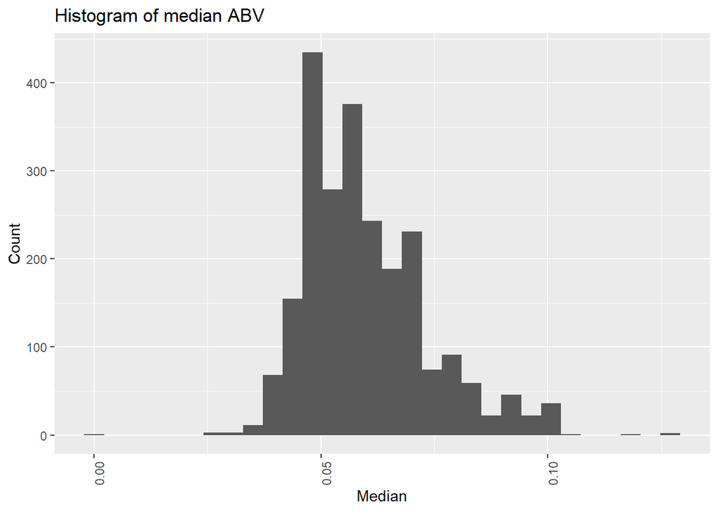

```r
abv_min <- min(df_merged_abv_cleaned$beer.abv)
abv_max <- max(df_merged_abv_cleaned$beer.abv)
abv_median <- median(df_merged_abv_cleaned$beer.abv)
abv_mean <- mean(df_merged_abv_cleaned$beer.abv)
abv_sd <- sd(df_merged_abv_cleaned$beer.abv)


df_merged_abv_cleaned %>%
  ggplot(aes(beer.abv)) +
  geom_histogram() +
  ggtitle("Histogram of median ABV") +
  labs(x = "Median", y = "Count") +
  theme(axis.text.x = element_text(angle = 90, hjust = 1))
```

## ABV Summary Statistics

| ABV Summary Statistics | Value |
| --- | --- |
| 1. Minimum | 0.001 |
| 2. Maximum | 0.128 |
| 3. Median | 0.056 |
| 4. Mean | 0.0598 |
| 5. Standard Deviation | 0.0135 |

# ABV vs IBU

Question Seven: Is there an apparent relationship between the bitterness of the beer and its alcoholic content? Draw a scatter plot. Make your best judgment of a relationship and EXPLAIN your answer.

- There appears to be a linear relationship between a beer’s International Bitterness Units (IBU) and the Alcohol by volume (ABV). The stronger a beer is, the more likely it is to rate higher on the bitterness scale.

## Scatterplot

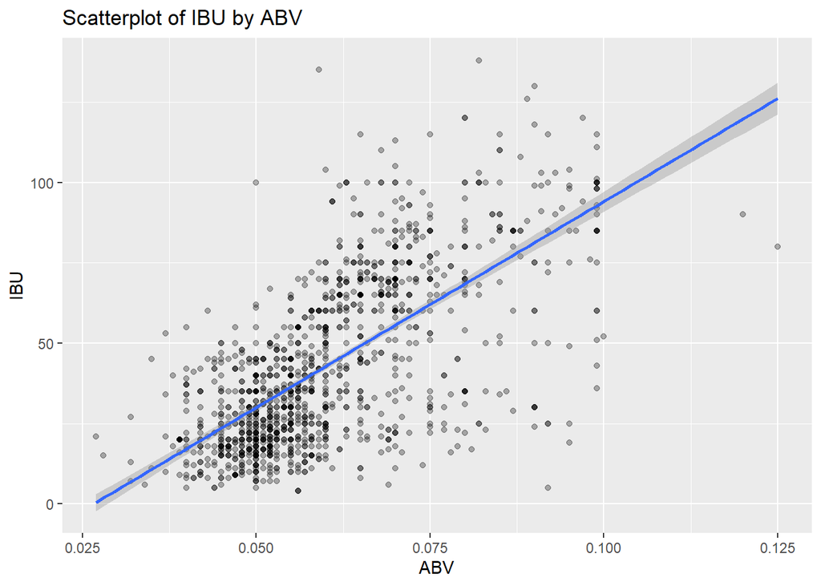

```r
df_merged %>%
  select(beer.abv, beer.ibu) %>%
  remove_missing(na.rm = TRUE) %>%
  ggplot(aes(x = beer.abv, y = beer.ibu)) +
  ggtitle("Scatterplot of IBU by ABV") +
  geom_point(alpha = 0.3) +
  labs(x = "ABV", y = "IBU") +
  # scale_x_continuous(breaks = seq(from = 0, to = 45, by = 2)) +
  geom_smooth(method = 'lm')
```

```r
df_abv_ibu_cor <- df_merged %>%
  select(beer.abv, beer.ibu)
```

## Pearson’s Correlation

```r
r <- cor(as.matrix(df_abv_ibu_cor), use="complete.obs")
r
```

```
##           beer.abv  beer.ibu
## beer.abv 1.0000000 0.6706215
## beer.ibu 0.6706215 1.0000000
```

## Correlation Test

- We estimate that this ratio falls within the interval of (0.6408, 0.6984) at the 95% confidence level.

```r
t <- cor.test(df_abv_ibu_cor$beer.abv, df_abv_ibu_cor$beer.ibu, use="complete.obs")
t
```

```
##
##  Pearson's product-moment correlation
##
## data:  df_abv_ibu_cor$beer.abv and df_abv_ibu_cor$beer.ibu
## t = 33.863, df = 1403, p-value < 2.2e-16
## alternative hypothesis: true correlation is not equal to 0
## 95 percent confidence interval:
##  0.6407982 0.6984238
## sample estimates:
##       cor
## 0.6706215
```

```r
# t$estimate
```

# 8. KNN

Question Eight: Budweiser would also like to investigate the difference with respect to IBU and ABV between IPAs (India Pale Ales) and other types of Ale (any beer with “Ale” in its name other than IPA). You decide to use KNN clustering to investigate this relationship. Provide statistical evidence one way or the other. You can of course assume your audience is comfortable with percentages … KNN is very easy to understand.

```r
df_merged$beer.ipa.vs.ale <- ''

df_merged$Population <- as.numeric(df_merged$Population)
df_merged$Income <- as.numeric(df_merged$Income)
# head(df_merged)
```

- Group by Beer Style and get counts for each

```r
df_merged %>%
  count(beer.style, sort = TRUE) %>%
  top_n(10)
```

```
## # A tibble: 10 x 2
##    beer.style                         n
##    <chr>                          <int>
##  1 American IPA                     424
##  2 American Pale Ale (APA)          245
##  3 American Amber / Red Ale         133
##  4 American Blonde Ale              108
##  5 American Double / Imperial IPA   105
##  6 American Pale Wheat Ale           97
##  7 American Brown Ale                70
##  8 American Porter                   68
##  9 Saison / Farmhouse Ale            52
## 10 Witbier                           51
```

```r
# kable(df_merged %>%
#   count(beer.style, sort = TRUE)) %>%
#   kable_styling(bootstrap_options = c("striped", "hover", "condensed", "responsive"))
```

- Five beers have not style available, one of which appears to be an Ale.

```r
df_merged %>%
  filter(beer.style == '')
```

```
##   beer.brewery.id                      beer.name beer.id beer.abv beer.ibu
## 1              30                Special Release    2210       NA       NA
## 2              67                  OktoberFiesta    2527    0.053       27
## 3             161 Kilt Lifter Scottish-Style Ale    1635    0.060       21
## 4             167                 The CROWLERâ„¢    1796       NA       NA
## 5             167           CAN'D AID Foundation    1790       NA       NA
##   beer.style beer.ounces brewery.state.abb               brewery.name
## 1                     16                TX        Cedar Creek Brewery
## 2                     12                TX   Freetail Brewing Company
## 3                     12                AZ Four Peaks Brewing Company
## 4                     32                CO        Oskar Blues Brewery
## 5                     12                CO        Oskar Blues Brewery
##   brewery.city state.name state.region Population Income beer.ipa.vs.ale
## 1 Seven Points      Texas        South      12237   4188
## 2  San Antonio      Texas        South      12237   4188
## 3        Tempe    Arizona         West       2212   4530
## 4     Longmont   Colorado         West       2541   4884
## 5     Longmont   Colorado         West       2541   4884
```

### IPAs

- We were able to clasify 560 beers as being IPAs
- American Double / Imperial IPA
- American IPA
- Belgian IPA
- English India Pale Ale (IPA)

```r
df_merged %>%
  filter(beer.style %in% c("American Double / Imperial IPA", "American IPA", "Belgian IPA", "English India Pale Ale (IPA)")) %>%
  count(beer.style)
```

```
## # A tibble: 4 x 2
##   beer.style                         n
##   <chr>                          <int>
## 1 American Double / Imperial IPA   105
## 2 American IPA                     424
## 3 Belgian IPA                       18
## 4 English India Pale Ale (IPA)      13
```

```r
df_ipa <- df_merged %>%
  filter(beer.style %in% c("American Double / Imperial IPA", "American IPA", "Belgian IPA", "English India Pale Ale (IPA)")) %>%
  mutate(beer.ipa.vs.ale = 'IPA')

# head(df_ipa)
```

### Other Ales

- We were able to clasify 964 beers as being Ales

```r
# Kilt Lifter Scottish-Style Ale (1635)
df_merged[946,]
```

```
##     beer.brewery.id                      beer.name beer.id beer.abv
## 946             161 Kilt Lifter Scottish-Style Ale    1635     0.06
##     beer.ibu beer.style beer.ounces brewery.state.abb
## 946       21                     12                AZ
##                   brewery.name brewery.city state.name state.region
## 946 Four Peaks Brewing Company        Tempe    Arizona         West
##     Population Income beer.ipa.vs.ale
## 946       2212   4530
```

```r
df_merged %>%
  filter(!beer.style %in% c("American Double / Imperial IPA", "American IPA", "Belgian IPA", "English India Pale Ale (IPA)")) %>%
  filter(str_detect(beer.style, "Ale") | beer.id==1635) %>%
  count(beer.style)
```

```
## # A tibble: 29 x 2
##    beer.style                   n
##    <chr>                    <int>
##  1 ""                           1
##  2 Abbey Single Ale             2
##  3 American Amber / Red Ale   133
##  4 American Black Ale          36
##  5 American Blonde Ale        108
##  6 American Brown Ale          70
##  7 American Dark Wheat Ale      7
##  8 American Pale Ale (APA)    245
##  9 American Pale Wheat Ale     97
## 10 American Strong Ale         14
## # ... with 19 more rows
```

```r
df_ale <- df_merged %>%
  filter(!beer.style %in% c("American Double / Imperial IPA", "American IPA", "Belgian IPA", "English India Pale Ale (IPA)")) %>%
  filter(str_detect(beer.style, "Ale") | beer.id==1635) %>%
  mutate(beer.ipa.vs.ale = 'Ale')

# head(df_ale)
```

### Rowbind the ipa and ale data frames

```r
total_beers_count <- dim(df_merged)[1]
ipa_count <- dim(df_ipa)[1]
ale_count <- dim(df_ale)[1]

df_combined_ale <- rbind(df_ipa, df_ale)

ipa_ale_count <- dim(df_combined_ale)[1]


# head(df_combined_ale)
```

| Column Name | Count | % of Total |
| --- | --- | --- |
| 1. IPA | 560 | 23.24 |
| 2. Other Ales | 964 | 40 |
| 3. Ales + IPAs | 1524 | 63.24 |

### ABV Boxplot

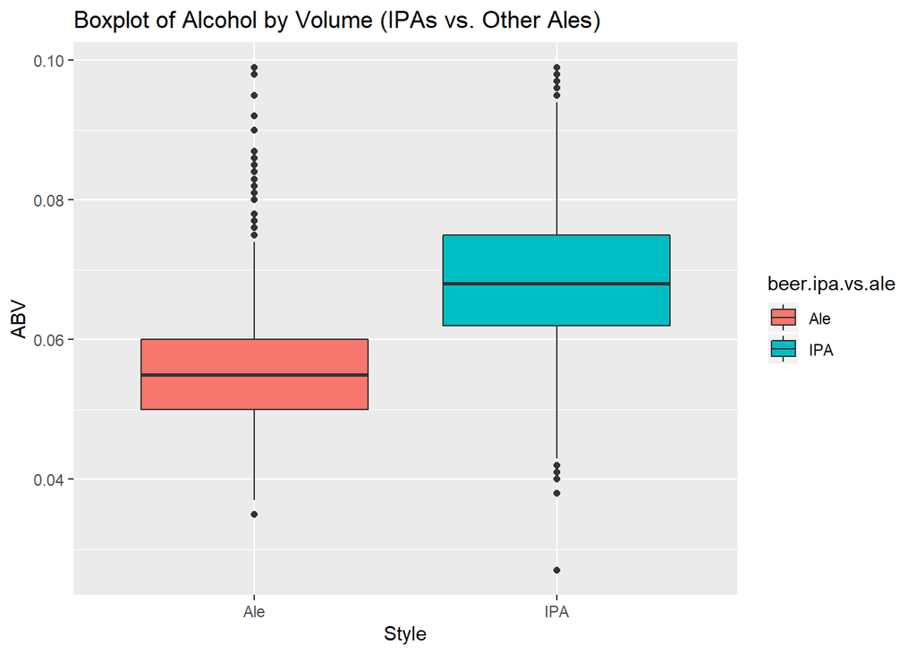

```r
df_combined_ale %>%
  filter(!is.na(beer.abv)) %>%
  ggplot(aes(x = beer.ipa.vs.ale, y = beer.abv, fill = beer.ipa.vs.ale)) +
  geom_boxplot() +
  ggtitle("Boxplot of Alcohol by Volume (IPAs vs. Other Ales)") +
  xlab("Style") +
  ylab("ABV")
```

### IBU Boxplot

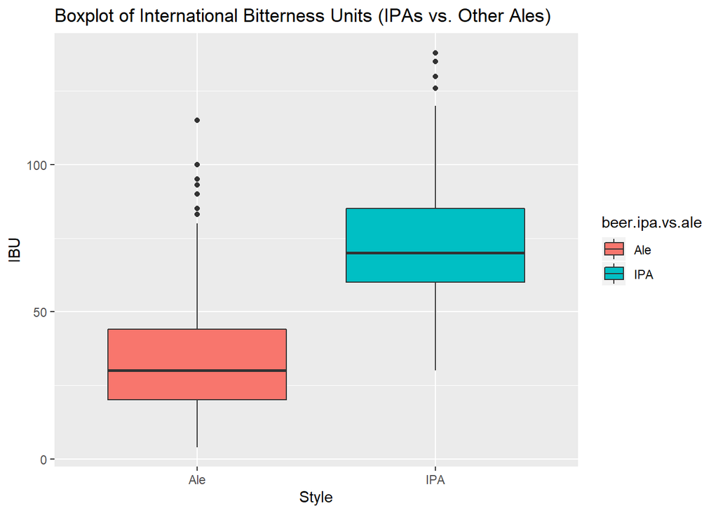

```r
df_combined_ale %>%
  filter(!is.na(beer.ibu)) %>%
  ggplot(aes(x = beer.ipa.vs.ale, y = beer.ibu, fill = beer.ipa.vs.ale)) +
  geom_boxplot() +
  ggtitle("Boxplot of International Bitterness Units (IPAs vs. Other Ales)") +
  xlab("Style") +
  ylab("IBU")
```

## Scatterplot

```r
df_classify <- df_combined_ale %>%
  filter(!is.na(beer.abv) & !is.na(beer.ibu))

df_classify %>%
  group_by(beer.ipa.vs.ale) %>%
  summarize(beers.abv.median = median(beer.abv), beers.ibu.median = median(beer.ibu), count = n())
```

```
## # A tibble: 2 x 4
##   beer.ipa.vs.ale beers.abv.median beers.ibu.median count
##   <chr>                      <dbl>            <dbl> <int>
## 1 Ale                       0.054                30   553
## 2 IPA                       0.0685               70   386
```

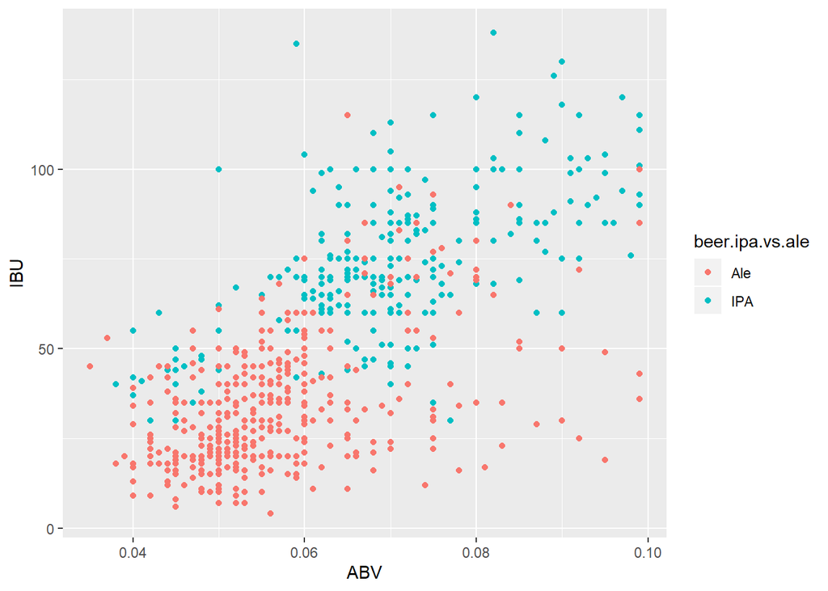

```r
df_classify %>%
  ggplot(aes(x = beer.abv, y = beer.ibu, color =  beer.ipa.vs.ale)) +
  xlab("ABV") + ylab("IBU") +
  geom_point()
```

```r
# df = data.frame(beer.abv = .07, beer.ibu = 50 )
# knn(df_combined_ale_cleaned[,c(4,5)], df, df_combined_ale_cleaned$beer.ipa.vs.ale, k = 5, prob = TRUE)
```

# Beer Style Predictions with KNN

- ABV and IBU served as good predictors of a beer’s style when available

```r
set.seed(1234)
split.perc = .70

# summary(df_classify)


# standardize values
df_classify$z.abv = scale(df_classify$beer.abv)
df_classify$z.ibu = scale(df_classify$beer.ibu)


train.indices = sample(1:dim(df_classify)[1],round(split.perc * dim(df_classify)[1]))

train = df_classify[train.indices,]
test = df_classify[-train.indices,]

dim(df_classify) # 939
```

```
## [1] 939  17
```

```r
dim(train) # 657
```

```
## [1] 657  17
```

```r
dim(test) #282
```

```
## [1] 282  17
```

```r
# original scale
classifications = knn(train[,c(4,5)],test[,c(4,5)], train$beer.ipa.vs.ale, prob = TRUE, k = 6)
# confusionMatrix(table(test$beer.ipa.vs.ale,classifications))

# standardized
classifications = knn(train[,c(16,17)],test[,c(16,17)], train$beer.ipa.vs.ale, prob = TRUE, k = 16)
confusionMatrix(table(test$beer.ipa.vs.ale,classifications))
```

```
## Confusion Matrix and Statistics
##
##      classifications
##       Ale IPA
##   Ale 146  18
##   IPA  16 102
##
##                Accuracy : 0.8794
##                  95% CI : (0.8356, 0.915)
##     No Information Rate : 0.5745
##     P-Value [Acc > NIR] : <2e-16
##
##                   Kappa : 0.7529
##
##  Mcnemar's Test P-Value : 0.8638
##
##             Sensitivity : 0.9012
##             Specificity : 0.8500
##          Pos Pred Value : 0.8902
##          Neg Pred Value : 0.8644
##              Prevalence : 0.5745
##          Detection Rate : 0.5177
##    Detection Prevalence : 0.5816
##       Balanced Accuracy : 0.8756
##
##        'Positive' Class : Ale
##
```

### Loop for many k and one training / test partition

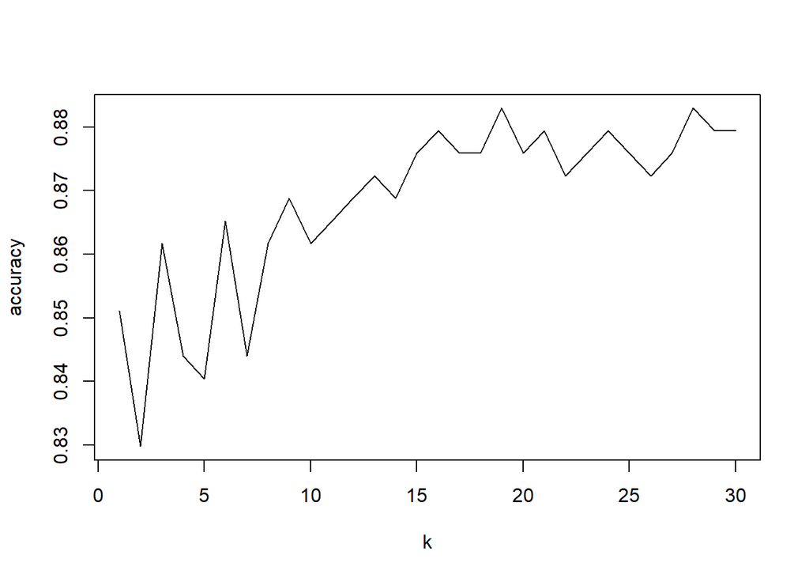

```r
acc = data.frame(accuracy = numeric(30), k = numeric(30))

for(i in 1:30)
{
  classifications = knn(train[,c(16,17)],test[,c(16,17)], train$beer.ipa.vs.ale, prob = TRUE, k = i)
  table(test$beer.ipa.vs.ale, classifications)
  CM = confusionMatrix(table(test$beer.ipa.vs.ale,classifications))
  acc$accuracy[i] = CM$overall[1]
  acc$k[i] = i
}

plot(acc$k,acc$accuracy, type = "l", xlab = "k", ylab="accuracy")
```

## Loop for many k and many training / test partitions

- this could also be seen when running many iterations of a train/ test split as one

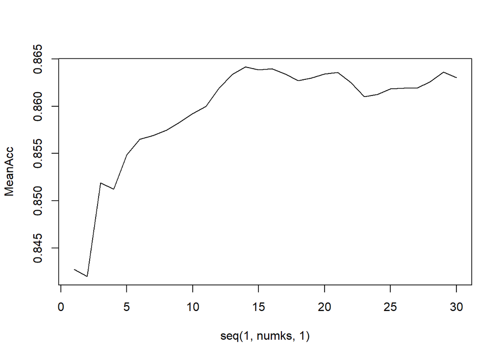

```r
iterations = 100
numks = 30


masterAcc = matrix(nrow = iterations, ncol = numks)

for(j in 1:iterations)
{
  train.indices = sample(1:dim(df_classify)[1],round(split.perc * dim(df_classify)[1]))
  train = df_classify[train.indices,]
  test = df_classify[-train.indices,]
  for(i in 1:numks)
  {
    classifications = knn(train[,c(16,17)],test[,c(16,17)], train$beer.ipa.vs.ale, prob = TRUE, k = i)
    table(test$beer.ipa.vs.ale, classifications)
    CM = confusionMatrix(table(test$beer.ipa.vs.ale,classifications))
    masterAcc[j,i] = CM$overall[1]
  }

}

MeanAcc = colMeans(masterAcc)

plot(seq(1,numks,1),MeanAcc, type = "l")
```

```r
which.max(MeanAcc)
```

```
## [1] 14
```

```r
max(MeanAcc)
```

```
## [1] 0.8641489
```

# Headmap of US Craft Beers by State

Question Nine: Knock their socks off! Find one other useful inference from the data that you feel Budweiser may be able to find value in. You must convince them why it is important and back up your conviction with appropriate statistical evidence.

```r
#count up the occurance of each state.
df_beer_count_by_state <- df_merged %>%
  count(state.name, sort = TRUE)

head(df_beer_count_by_state)
```

```
## # A tibble: 6 x 2
##   state.name     n
##   <chr>      <int>
## 1 Colorado     265
## 2 California   183
## 3 Michigan     162
## 4 Indiana      139
## 5 Texas        130
## 6 Oregon       125
```

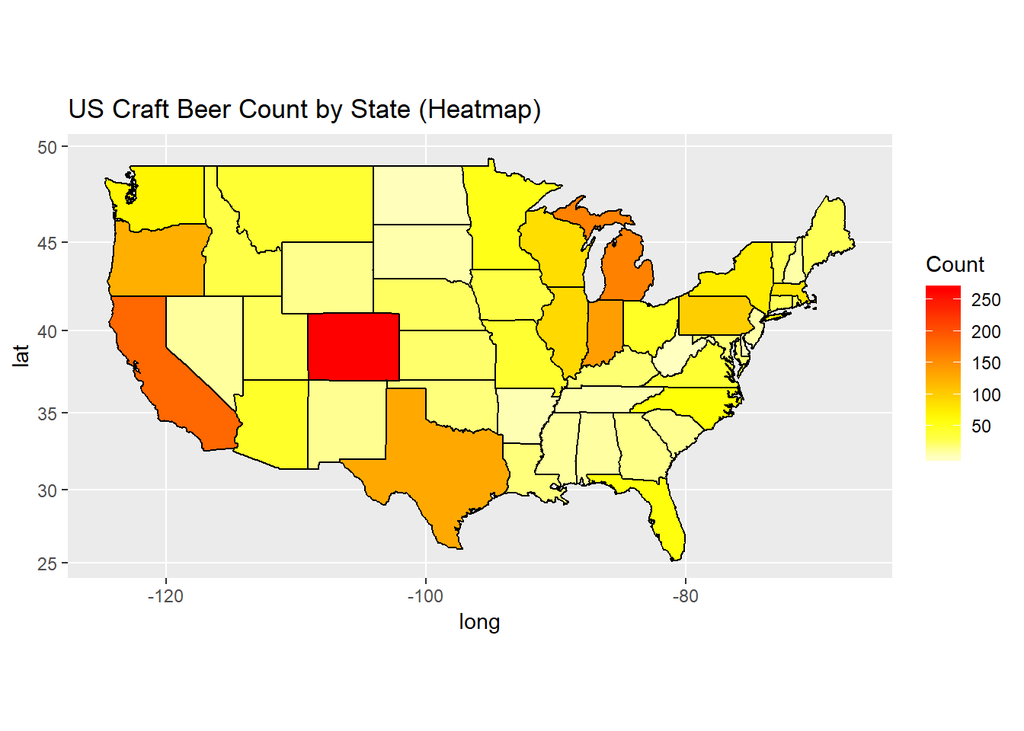

```r
colnames(df_beer_count_by_state)[1] = "State" #change "state.name" to "State"
colnames(df_beer_count_by_state)[2] = "Count" #change "n" to "Count"

# df_abv_map_data1

df_beer_count_by_state$region <- tolower(df_beer_count_by_state$State)
df_beer_count_by_state2 <- df_beer_count_by_state[-1]
states <- map_data("state")
map.df <- merge(states, df_beer_count_by_state2, by="region", all.x=T)
map.df <- map.df[order(map.df$order),]
ggplot(map.df, aes(x=long,y=lat,group=group))+
  geom_polygon(aes(fill=Count))+
  geom_path()+
  scale_fill_gradientn(colours=rev(heat.colors(10)),na.value="grey90")+ggtitle("US Craft Beer Count by State (Heatmap)")+
coord_map()
```

# Barplot of Craft Beers by Region

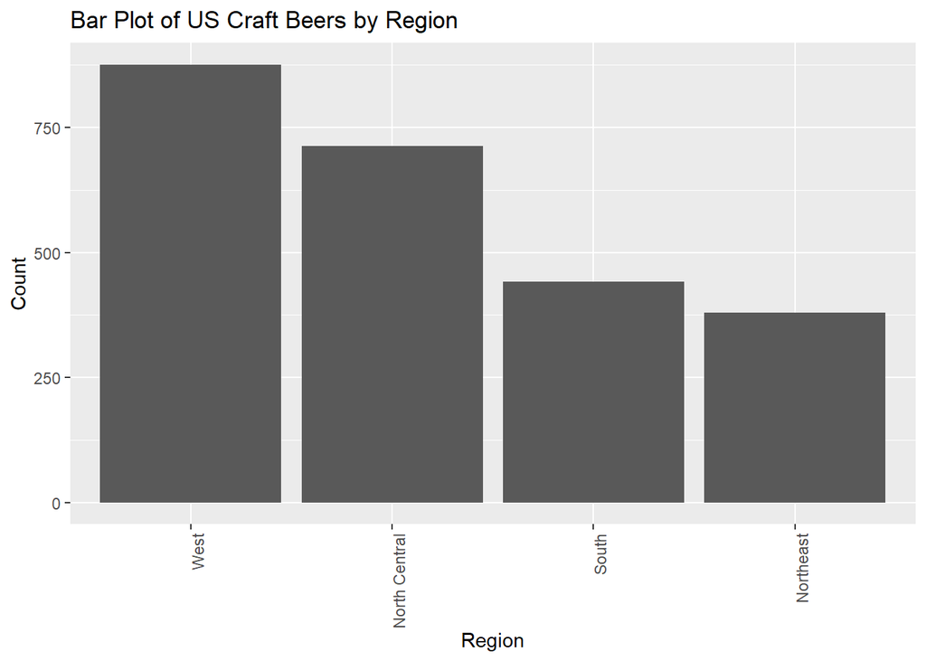

```r
#count up the occurance of each state.
df_beer_count_by_region <- df_merged %>%
  count(state.region, sort = TRUE) %>%
  ggplot(aes(x = reorder(state.region, -n), y=n)) +
  geom_bar(stat = "identity", position = "dodge") +
  ggtitle("Bar Plot of US Craft Beers by Region") +
  labs(x = "Region", y = "Count") +
  theme(axis.text.x = element_text(angle = 90, hjust = 1))


df_beer_count_by_region
```

```r
# df_merged %>%
#   count(state.region, sort = TRUE) %>%
#   ggplot(aes(x = reorder(state.region, -n), y=n)) +
#   geom_bar(stat = "identity", position = "dodge") +
#   # ggtitle("Brewery Count by Region") +
#   labs(x = "Region", y = "Count") +
#   ggtitle("US Craft Beer Count by Region")
```

# Headmap of Median ABV by State

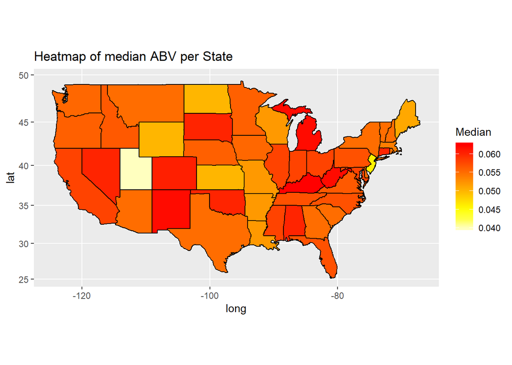

```r
#count up the occurance of each state.
df_merged_abv_median.heatmap <- df_merged_abv_median

# head(df_merged_abv_median.heatmap)


colnames(df_merged_abv_median.heatmap)[1] = "State" #change "state.name" to "State"
colnames(df_merged_abv_median.heatmap)[2] = "Median" #change "n" to "Count"

# df_abv_map_data1

df_merged_abv_median.heatmap$region <- tolower(df_merged_abv_median.heatmap$State)
df_merged_abv_median.heatmap2 <- df_merged_abv_median.heatmap[-1]
states <- map_data("state")
map.df <- merge(states, df_merged_abv_median.heatmap2, by="region", all.x=T)
map.df <- map.df[order(map.df$order),]
ggplot(map.df, aes(x=long,y=lat,group=group))+
  geom_polygon(aes(fill=Median))+
  geom_path()+
  scale_fill_gradientn(colours=rev(heat.colors(10)),na.value="grey90")+ggtitle("Heatmap of median ABV per State")+
coord_map()
```

# Headmap of Median IBU by State

- No craft beers with IBU ratings for South Dakota

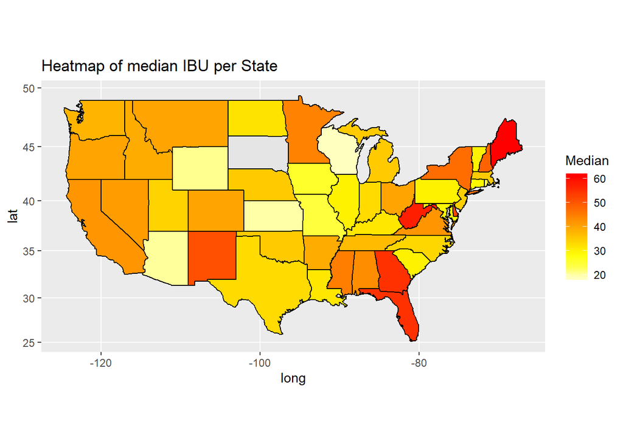

```r
df_merged_ibu_median.heatmap <- df_merged_ibu_median

# head(df_merged_ibu_median.heatmap)


colnames(df_merged_ibu_median.heatmap)[1] = "State" #change "state.name" to "State"
colnames(df_merged_ibu_median.heatmap)[2] = "Median" #change "n" to "Count"

# df_abv_map_data1

df_merged_ibu_median.heatmap$region <- tolower(df_merged_ibu_median.heatmap$State)
df_merged_ibu_median.heatmap2 <- df_merged_ibu_median.heatmap[-1]
states <- map_data("state")
map.df <- merge(states, df_merged_ibu_median.heatmap2, by="region", all.x=T)
map.df <- map.df[order(map.df$order),]
ggplot(map.df, aes(x=long,y=lat,group=group))+
  geom_polygon(aes(fill=Median))+
  geom_path()+
  scale_fill_gradientn(colours=rev(heat.colors(10)),na.value="grey90")+ggtitle("Heatmap of median IBU per State")+
coord_map()
```

# Conclusion

We were able to ascertain that a beer’s Alcohol by Volume (ABV) and International Bitterness Units (IBU) served as good predictors of beer styles for IPAs and other Ale types. There was also evidence of regional references in a beer’s bitterness. Because of the relatively few craft beers bottled and distributed from the Northeast and South regions, we expect there to be greater market opportunities for the Budweiser family of beverages in states like Maine, Florida and West Virginia where the median bitterness of beers is somewhat higher than other areas.

We hope that from this observational study, we can proceed with more sophisticated experimental designs where causal conclusions can be drawn. Additionally, we expect that expanding the factors of the study to include other points of interest while minimizing the missingness of the central bitterness parameter could be beneficial for any further analysis and predictive accuracy.